# Freiberg Short Sourse – Exploration of Earth Science Data

Detrital Zircon Provenance Analysis

Tobias Stephan

9 - 13 October 2023

The subjective comparison of individual zircon age spectra with each other or with likely source areas is in many cases inadequate, as the pattern may be changed during erosion of the source and transport to the sink and, therefore, the similarity of pattern alone is not always conclusive (e.g. Blatt, 1967; Dickinson & Gehrels, 2009a; Hietpas et al. 2011; Zimmermann et al. 2015).

Some of these problems may be reduced or avoided by using large, compiled datasets and applying quantitative filtering and data evaluation techniques. Statistical data analysis has become possible because of the increasing number of high-quality datasets on the age distribution of detrital zircons.

```r
library(readxl)
library(IsoplotR)
library(provenance)
library(dplyr)
library(tidyr)
library(qpcR)
library(ggplot2)
library(patchwork)
library(factoextra)
```

## The pre-orogenic detrital zircon record the Variscides

load ages and samples from Stephan et al. (2019)

```r
samples_all <- readxl::read_xlsx("Stephan2019_samples.xlsx", skip = 2)
ages_all <- read_xlsx("Stephan2019_ages.xlsx") |>
  mutate(Error_percent = Error_2s / Age * 100)

nrow(samples_all)
```

```
## [1] 451
```

```r
ages_all |>
  summary()
```

```
##   Reference            Sample              Spot                ThU
##  Length:63050       Length:63050       Length:63050       Min.   : -13.240
##  Class :character   Class :character   Class :character   1st Qu.:   0.325
##  Mode  :character   Mode  :character   Mode  :character   Median :   0.566
##                                                           Mean   :   6.893
##                                                           3rd Qu.:   0.974
##                                                           Max.   :1528.292
##                                                           NA's   :25766
##   Discordance            Age              Error_2s        Error_percent
##  Min.   : -93.977   Min.   :   9.263   Min.   :    0.16   Min.   :   0.054
##  1st Qu.:  -2.125   1st Qu.: 578.321   1st Qu.:   10.63   1st Qu.:   1.425
##  Median :  -0.587   Median : 716.553   Median :   17.13   Median :   2.107
##  Mean   :   7.677   Mean   :1129.981   Mean   :   52.21   Mean   :   3.808
##  3rd Qu.:   0.222   3rd Qu.:1573.938   3rd Qu.:   34.14   3rd Qu.:   3.161
##  Max.   :5944.664   Max.   :5000.000   Max.   :34389.63   Max.   :3128.385
##                     NA's   :7678       NA's   :7678       NA's   :7678
```

Filter

1. Pre-orogenic samples (i.e. deposition age of samples older than 400 Ma – the onset of Variscan orogeny)
2. Concordant DZ ages (Concordance = 1-Discordance, Discordance filter = [-10%, 20%]))
3. Most of the Gondwana shelf was delivered by Cadomian detritus (not a diagnostic provenance feature), thus, DZ age >= 700 Ma
4. Statistical significance: only include samples with >= 30 DZ ages

```r
ages <- ages_all |>
  filter(
    Error_2s <= 50,
    between(Discordance, -10, 20),
    between(Age, 700, 4500)
  ) |>
  dplyr::select(c(Sample, Age, Error_2s))
```

samples that do have enough ages to be significant (>=30)

```r
signif_samples <- ages |>
  group_by(Sample) |>
  summarise(n = n()) |>
  filter(n >= 30) |>
  pull(Sample)

length(signif_samples)
```

```
## [1] 280
```

join filtered age dataset with sample dataset and omit the insignificant samples

```r
data <- left_join(samples_all, ages, by = "Sample") %>%
  filter(
    Sample %in% signif_samples,
    `Sample age` >= 400
    ) %>%
  slice_sample(prop = 1)
```

For analysis we follow Vermeesch (2013)

Prepare for P. Vermeesch’s `provenance` package

```r
c_ages <- c_error <- c()
for (i in unique(data$Sample)) {
  ai <- filter(data, Sample == i)
  agesi <- c(ai$Age)
  erri <- c(ai$Error_2s)
  c_ages <- qpcR:::cbind.na(c_ages, agesi)
  c_error <- qpcR:::cbind.na(c_error, agesi)
}
c_ages <- c_ages[, -1]
c_error <- c_error[, -1]
colnames(c_ages) <- colnames(c_error) <- unique(data$Sample)

DZ <- list()
class(DZ) <- "distributional"
for (i in 1:ncol(c_ages)) {
  good <- !is.na(c_ages[, i])
  if (any(good)) {
    DZ$x[[colnames(c_ages)[i]]] <- c_ages[good, i]
  }
  DZ$err[[colnames(c_ages)[i]]] <- c_error[good, i]
}
```

### Quantify the dissimilarities

Create a **matrix dissimilarity matrix** representing the “distances” between pairs of objects.

Calculate the dissimilarities of each sample pair using the “Wasserstein-2 distance” (Lipp & Vermeesch, 2021, *Geochronology*)

```r
DZ_diss <- provenance::Wasserstein.diss(DZ)
```

Visualize the dissimilarities matrix:

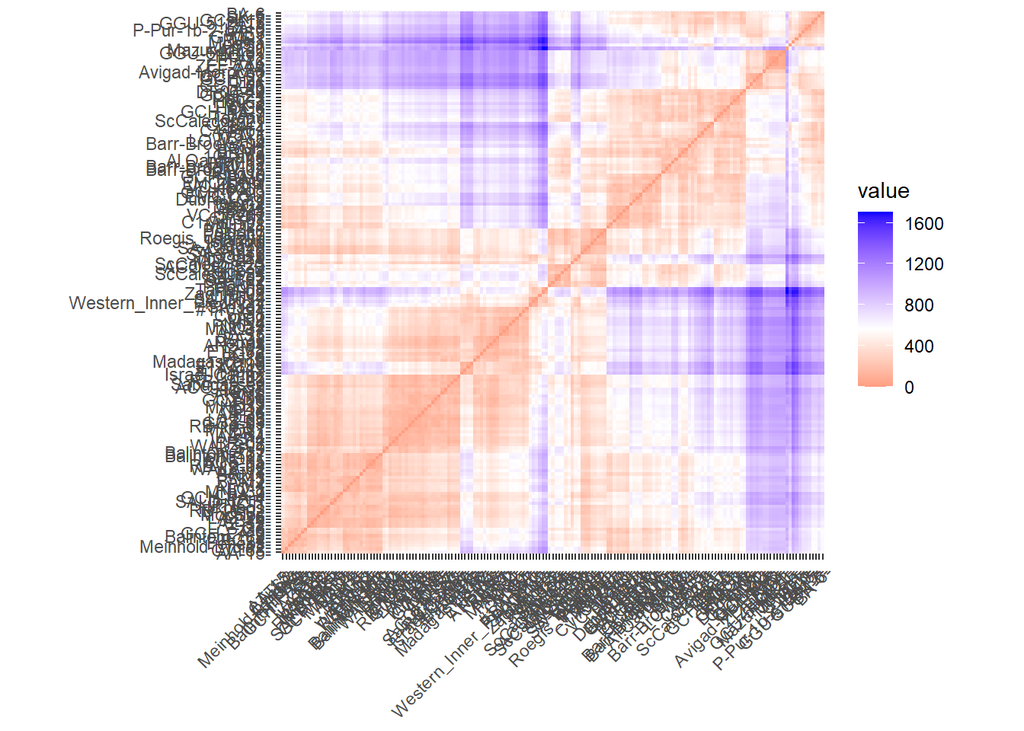

### Multidimensional scaling (MDS)

Multidimensional scaling (**MDS**) is a multivariate data analysis approach that is used to visualize the similarity/dissimilarity between samples by plotting points in two dimensional plots.

The MDS algorithm takes as an input data the dissimilarity matrix:

```r
DZ_mds <- provenance::MDS(DZ_diss, k = 3)
```

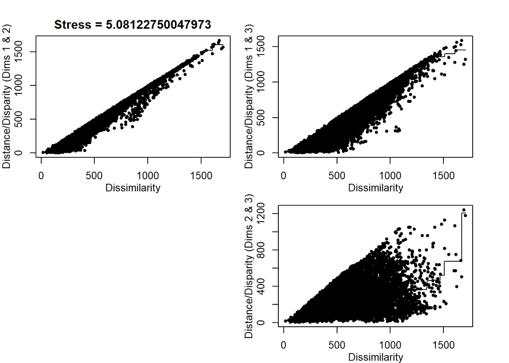

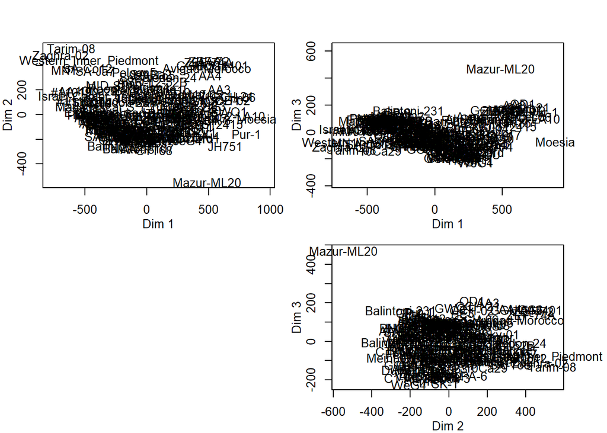

```r
plot(DZ_mds)
```

### Cluster analysis

Cluster the dissimilarity matrix to group similar samples

Density-based Spatial Clustering of Applications with Noise (**DBSCAN**)

```r
DZ_clust <- dbscan::dbscan(DZ_diss, eps = 190, minPts = 5)
DZ_clust
```

```
## DBSCAN clustering for 167 objects.
## Parameters: eps = 190, minPts = 5
## Using unknown distances and borderpoints = TRUE
## The clustering contains 5 cluster(s) and 40 noise points.
##
##  0  1  2  3  4  5
## 40 85 15  6 16  5
##
## Available fields: cluster, eps, minPts, dist, borderPoints
```

### Plot the final results

```r
DZ_res <- DZ_mds$points |>
  as_tibble() |>
  mutate(
    Sample = rownames(DZ_mds$points),
    cluster = DZ_clust$cluster,
    cluster = as.factor(ifelse(cluster == 0, NA, cluster))
  ) |>
  rename(Dim1 = V1, Dim2 = V2, Dim3 = V3) |>
  left_join(samples_all)
```

Plot the MDS dimension `Dim1`, `Dim2`, and `Dim3` as biplots:

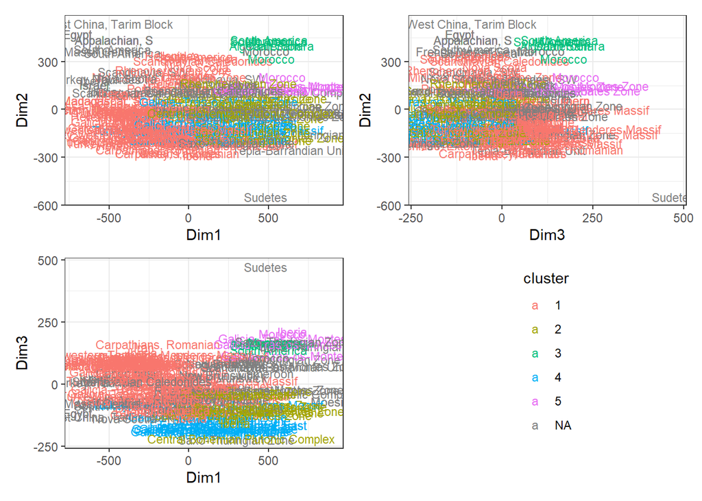

```r
plot1 <- ggplot(data = DZ_res, aes(Dim1, Dim2, label = Location, color = cluster)) + # Dim1 vs Dim 2
  geom_text(size = 3)
plot2 <- ggplot(data = DZ_res, aes(Dim3, Dim2, label = Location, color = cluster)) + # Dim3 vs Dim 2
  geom_text(size = 3)
plot3 <- ggplot(data = DZ_res, aes(Dim1, Dim3, label = Location, color = cluster)) + # Dim1 vs Dim 3
  geom_text(size = 3)

# combine the three plots into one
plot1 + plot2 + plot3 + guide_area() +
  plot_layout(guides = "collect") &
  theme_bw()
```

Show the spatial distribution of the DZ clusters

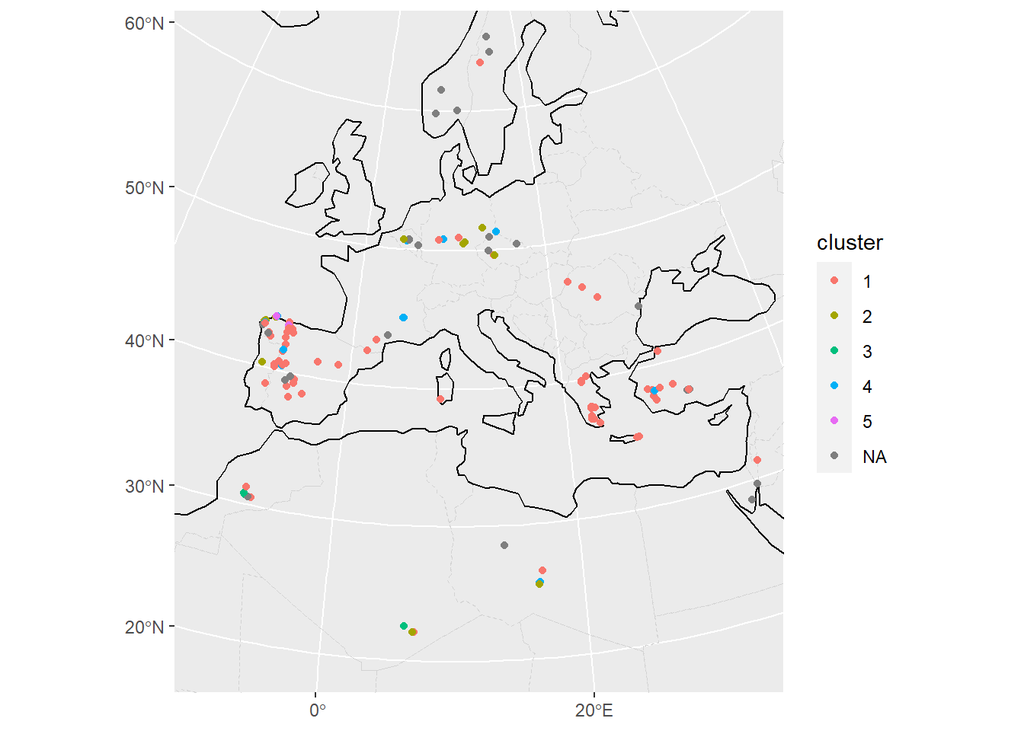

```r
library(rnaturalearth)
coastlines <- rnaturalearth::ne_coastline(returnclass = "sf")
states <- rnaturalearth::ne_countries(returnclass = "sf")

DZ_res |>
  sf::st_as_sf(coords = c("Long WGS", "Lat WGS"), crs = "WGS84", remove = FALSE) |>
  ggplot() +
  geom_sf(data = states, fill = NA, lty = 2, color = "lightgrey", inherit.aes = FALSE) +
  geom_sf(data = coastlines, inherit.aes = FALSE) +
  geom_sf(aes(color = cluster)) +
  coord_sf(xlim = c(-15, 40), ylim = c(20, 65), crs = "EPSG:3035", default_crs = "WGS84")
```

Show the age spectra of the DZ cluster using KDE density diagrams (Vermeesch, 2012)

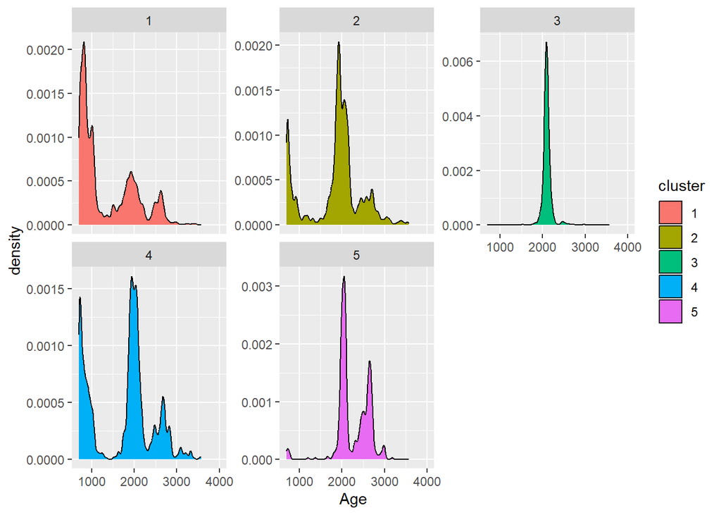

```r
left_join(ages, DZ_res) |> # merge the ages dataset with the statistical results
  filter(!is.na(cluster)) |> # remove the statistical outliers
  ggplot() +
  geom_density(aes(Age, fill = cluster), bw = 30) + # density of ages for binwidth "bw"
  facet_wrap(vars(cluster), scales = "free_y") + # create a plot for each unique feature in "cluster"
  coord_cartesian(xlim = c(700, 4000)) # limits of the x axis
```